# Regression Analysis Project

### statistics of the data

```python
data.describe(include ='all')
```

|  | Ship_name | Cruise_line | Age | Tonnage | passengers | length | cabins | passenger_density | crew |
| --- | --- | --- | --- | --- | --- | --- | --- | --- | --- |
| count | 158 | 158 | 158.000000 | 158.000000 | 158.000000 | 158.000000 | 158.000000 | 158.000000 | 158.000000 |
| unique | 138 | 20 | NaN | NaN | NaN | NaN | NaN | NaN | NaN |
| top | Spirit | Royal_Caribbean | NaN | NaN | NaN | NaN | NaN | NaN | NaN |
| freq | 4 | 23 | NaN | NaN | NaN | NaN | NaN | NaN | NaN |
| mean | NaN | NaN | 15.689873 | 71.284671 | 18.457405 | 8.130633 | 8.830000 | 39.900949 | 7.794177 |
| std | NaN | NaN | 7.615691 | 37.229540 | 9.677095 | 1.793474 | 4.471417 | 8.639217 | 3.503487 |
| min | NaN | NaN | 4.000000 | 2.329000 | 0.660000 | 2.790000 | 0.330000 | 17.700000 | 0.590000 |
| 25% | NaN | NaN | 10.000000 | 46.013000 | 12.535000 | 7.100000 | 6.132500 | 34.570000 | 5.480000 |
| 50% | NaN | NaN | 14.000000 | 71.899000 | 19.500000 | 8.555000 | 9.570000 | 39.085000 | 8.150000 |
| 75% | NaN | NaN | 20.000000 | 90.772500 | 24.845000 | 9.510000 | 10.885000 | 44.185000 | 9.990000 |
| max | NaN | NaN | 48.000000 | 220.000000 | 54.000000 | 11.820000 | 27.000000 | 71.430000 | 21.000000 |

```python
data.isnull().sum()
```

```
Ship_name            0
Cruise_line          0
Age                  0
Tonnage              0
passengers           0
length               0
cabins               0
passenger_density    0
crew                 0
dtype: int64
```

### Finding predicting variable

```python
cols = ['Age', 'Tonnage', 'passengers', 'length', 'cabins','passenger_density','crew']
from sklearn.preprocessing import StandardScaler
stdsc = StandardScaler()
X_std = stdsc.fit_transform(data[cols].iloc[:,range(0,7)].values)
```

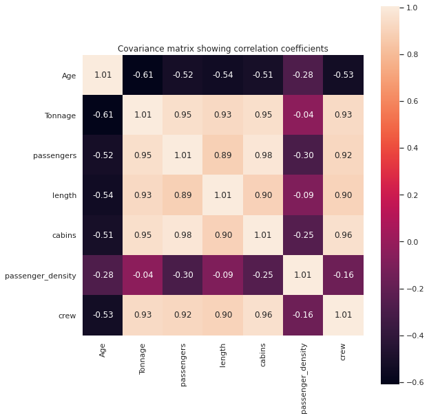

```python
cov_mat =np.cov(X_std.T)
plt.figure(figsize=(9,9))
sns.set(font_scale=1)
hm = sns.heatmap(cov_mat,
                 cbar=True,
                 annot=True,
                 square=True,
                 fmt='.2f',
                 annot_kws={'size': 12},
                 yticklabels=cols,
                 xticklabels=cols)
plt.title('Covariance matrix showing correlation coefficients')
plt.tight_layout()
plt.show()
```

From this matrix we can clearly see that Tonnage, passengers, length, cabins are highly correlated with crew variables so we have found out the predictive variables

```python
col_selected = ['Tonnage','passengers','length','cabins','crew']
```

```python
data[col_selected]
```

|  | Tonnage | passengers | length | cabins | crew |
| --- | --- | --- | --- | --- | --- |
| 0 | 30.277 | 6.94 | 5.94 | 3.55 | 3.55 |
| 1 | 30.277 | 6.94 | 5.94 | 3.55 | 3.55 |
| 2 | 47.262 | 14.86 | 7.22 | 7.43 | 6.70 |
| 3 | 110.000 | 29.74 | 9.53 | 14.88 | 19.10 |
| 4 | 101.353 | 26.42 | 8.92 | 13.21 | 10.00 |
| ... | ... | ... | ... | ... | ... |
| 153 | 3.341 | 0.66 | 2.79 | 0.33 | 0.59 |
| 154 | 76.800 | 19.60 | 8.79 | 9.67 | 12.00 |
| 155 | 5.350 | 1.58 | 4.40 | 0.74 | 0.88 |
| 156 | 5.350 | 1.67 | 4.40 | 0.74 | 0.88 |
| 157 | 14.745 | 3.08 | 6.17 | 1.56 | 1.80 |

158 rows × 5 columns

### Nature of predictive variabales

```python
import seaborn as sns
```

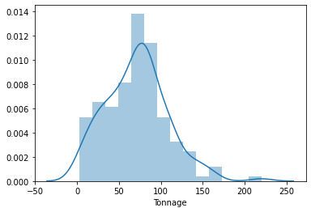

```python
sns.distplot(data['Tonnage'])
```

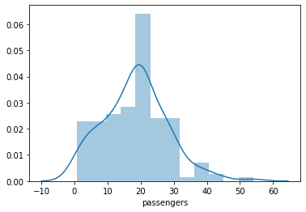

```python
sns.distplot(data['passengers'])
```

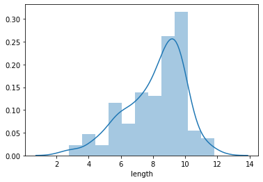

```python
sns.distplot(data['length'])
```

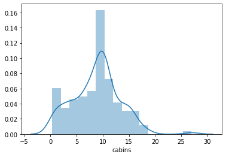

```python
sns.distplot(data['cabins'])
```

# One-hot encoding for categorical features

```python
data_with_dummies = pd.get_dummies(data, drop_first=True)
```

```python
data_with_dummies.head()
```

|  | Age | Tonnage | passengers | length | cabins | passenger_density | crew | Ship_name_Allegra | Ship_name_Amsterdam | Ship_name_Arcadia | ... | Cruise_line_Oceania | Cruise_line_Orient | Cruise_line_P&O | Cruise_line_Princess | Cruise_line_Regent_Seven_Seas | Cruise_line_Royal_Caribbean | Cruise_line_Seabourn | Cruise_line_Silversea | Cruise_line_Star | Cruise_line_Windstar |
| --- | --- | --- | --- | --- | --- | --- | --- | --- | --- | --- | --- | --- | --- | --- | --- | --- | --- | --- | --- | --- | --- |
| 0 | 6 | 30.277 | 6.94 | 5.94 | 3.55 | 42.64 | 3.55 | 0 | 0 | 0 | ... | 0 | 0 | 0 | 0 | 0 | 0 | 0 | 0 | 0 | 0 |
| 1 | 6 | 30.277 | 6.94 | 5.94 | 3.55 | 42.64 | 3.55 | 0 | 0 | 0 | ... | 0 | 0 | 0 | 0 | 0 | 0 | 0 | 0 | 0 | 0 |
| 2 | 26 | 47.262 | 14.86 | 7.22 | 7.43 | 31.80 | 6.70 | 0 | 0 | 0 | ... | 0 | 0 | 0 | 0 | 0 | 0 | 0 | 0 | 0 | 0 |
| 3 | 11 | 110.000 | 29.74 | 9.53 | 14.88 | 36.99 | 19.10 | 0 | 0 | 0 | ... | 0 | 0 | 0 | 0 | 0 | 0 | 0 | 0 | 0 | 0 |
| 4 | 17 | 101.353 | 26.42 | 8.92 | 13.21 | 38.36 | 10.00 | 0 | 0 | 0 | ... | 0 | 0 | 0 | 0 | 0 | 0 | 0 | 0 | 0 | 0 |

5 rows × 163 columns

```python
data_with_dummies.columns.values
```

```
array(['Age', 'Tonnage', 'passengers', 'length', 'cabins',
       'passenger_density', 'crew', 'Ship_name_Allegra',
       'Ship_name_Amsterdam', 'Ship_name_Arcadia', 'Ship_name_Aries',
       'Ship_name_Armonia', 'Ship_name_Artemis', 'Ship_name_Atlantica',
       'Ship_name_Aurora', 'Ship_name_Brilliance', 'Ship_name_Caribbean',
       'Ship_name_Celebration', 'Ship_name_Century', 'Ship_name_Classica',
       'Ship_name_Cloud', 'Ship_name_Conquest', 'Ship_name_Constellation',
       'Ship_name_Coral', 'Ship_name_Crown', 'Ship_name_Dawn',
       'Ship_name_Destiny', 'Ship_name_Diamond', 'Ship_name_Dream',
       'Ship_name_Ecstasy', 'Ship_name_Elation', 'Ship_name_Emerald',
       'Ship_name_Empress', 'Ship_name_Enchantment', 'Ship_name_Eurodam',
       'Ship_name_Europa', 'Ship_name_Explorer', 'Ship_name_ExplorerII',
       'Ship_name_Fantasia', 'Ship_name_Fantasy', 'Ship_name_Fascination',
       'Ship_name_Fortuna', 'Ship_name_Freedom', 'Ship_name_Galaxy',
       'Ship_name_Gem', 'Ship_name_Gemini', 'Ship_name_Glory',
       'Ship_name_Golden', 'Ship_name_Grand', 'Ship_name_Grandeur',
       'Ship_name_Holiday', 'Ship_name_Imagination',
       'Ship_name_Independence', 'Ship_name_Infinity',
       'Ship_name_Insignia', 'Ship_name_Inspiration', 'Ship_name_Island',
       'Ship_name_Jewel', 'Ship_name_Journey', 'Ship_name_Legend',
       'Ship_name_Liberty', 'Ship_name_Liberty*', 'Ship_name_Libra',
       'Ship_name_Lirica', 'Ship_name_Maasdam', 'Ship_name_Magic',
       'Ship_name_Magica', 'Ship_name_Majesty', 'Ship_name_MarcoPolo',
       'Ship_name_Marina', 'Ship_name_Mariner', 'Ship_name_Mediterranea',
       'Ship_name_Melody', 'Ship_name_Mercury', 'Ship_name_Millenium',
       'Ship_name_Miracle', 'Ship_name_Monarch', 'Ship_name_Musica',
       'Ship_name_Nautica', 'Ship_name_Navigator', 'Ship_name_Noordam',
       'Ship_name_Oasis', 'Ship_name_Oceana', 'Ship_name_Oosterdam',
       'Ship_name_Opera', 'Ship_name_Oriana', 'Ship_name_Pacific',
       'Ship_name_Paradise', 'Ship_name_PaulGauguin', 'Ship_name_Pisces',
       'Ship_name_Pride', 'Ship_name_PrideofAloha',
       'Ship_name_PrideofAmerica', 'Ship_name_Prinsendam',
       'Ship_name_QueenElizabethII', 'Ship_name_QueenMary2',
       'Ship_name_QueenVictoria', 'Ship_name_Quest', 'Ship_name_Radiance',
       'Ship_name_Regal', 'Ship_name_Regatta', 'Ship_name_Rhapsody',
       'Ship_name_Romantica', 'Ship_name_Rotterdam', 'Ship_name_Royal',
       'Ship_name_Ryndam', 'Ship_name_Saphire', 'Ship_name_Sea',
       'Ship_name_Sensation', 'Ship_name_Serena', 'Ship_name_Serenade',
       'Ship_name_Serenity', 'Ship_name_Shadow', 'Ship_name_Sinfonia',
       'Ship_name_Solstice', 'Ship_name_Sovreign', 'Ship_name_Spirit',
       'Ship_name_Splendour', 'Ship_name_Star', 'Ship_name_Statendam',
       'Ship_name_Summit', 'Ship_name_Sun', 'Ship_name_Surf',
       'Ship_name_Symphony', 'Ship_name_Tahitian', 'Ship_name_Taurus',
       'Ship_name_Triumph', 'Ship_name_Valor', 'Ship_name_Veendam',
       'Ship_name_Ventura', 'Ship_name_Victoria', 'Ship_name_Victory',
       'Ship_name_Virgo', 'Ship_name_Vision', 'Ship_name_Volendam',
       'Ship_name_Voyager', 'Ship_name_Westerdam', 'Ship_name_Whisper',
       'Ship_name_Wind', 'Ship_name_Wonder', 'Ship_name_Xpedition',
       'Ship_name_Zaandam', 'Ship_name_Zenith', 'Ship_name_Zuiderdam',
       'Cruise_line_Carnival', 'Cruise_line_Celebrity',
       'Cruise_line_Costa', 'Cruise_line_Crystal', 'Cruise_line_Cunard',
       'Cruise_line_Disney', 'Cruise_line_Holland_American',
       'Cruise_line_MSC', 'Cruise_line_Norwegian', 'Cruise_line_Oceania',
       'Cruise_line_Orient', 'Cruise_line_P&O', 'Cruise_line_Princess',
       'Cruise_line_Regent_Seven_Seas', 'Cruise_line_Royal_Caribbean',
       'Cruise_line_Seabourn', 'Cruise_line_Silversea',
       'Cruise_line_Star', 'Cruise_line_Windstar'], dtype=object)
```

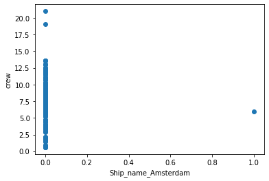

```python
plt.scatter(data_with_dummies['Ship_name_Amsterdam'],data_with_dummies['crew'])
plt.xlabel('Ship_name_Amsterdam')
plt.ylabel('crew')
plt.show()
```

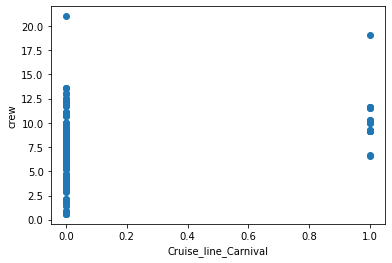

```python
plt.scatter(data_with_dummies['Cruise_line_Carnival'],data_with_dummies['crew'])
plt.xlabel('Cruise_line_Carnival')
plt.ylabel('crew')
plt.show()
```

In order to build a simplified regression model, we are just focusing on ordinal features. The categorical features "Ship_name" and "Cruise_line" will not be used. We are only using theese 4 ordinal features "Tonnage", "passengers", "length, and "cabins" variables.

```python
df=data_with_dummies.copy()
```